```python
import sys
print("Interpreter:", sys.executable)
print("Python:", sys.version)

# Optional: confirm core libs
try:
    import numpy as np
    import pandas as pd
    import matplotlib
    print("numpy:", np.__version__)
    print("pandas:", pd.__version__)
    print("matplotlib:", matplotlib.__version__)
except Exception as e:
    print("Package check error:", e)
```

```
Interpreter: c:\repos\Signals-and-sensors---Yrgo\.venv\Scripts\python.exe
Python: 3.11.9 (tags/v3.11.9:de54cf5, Apr  2 2024, 10:12:12) [MSC v.1938 64 bit (AMD64)]
numpy: 2.3.3
pandas: 2.3.2
matplotlib: 3.10.6
```

# Frequency Analysis – Lab Report (ELA24)

## Introduction

A central concept in signal processing is that signals can be represented both in the time domain and in the frequency domain. Fourier series allow us to express a periodic signal as a sum of sinusoidal components. The sharper the edges in the time domain, the slower the decay of harmonic amplitudes. This experiment provides hands-on experience with Fourier analysis of canonical signals and prepares you to relate time‑domain features to frequency‑domain spectra.

## Experiment

### Equipment

- Oscilloscope + Function Generator: Keysight DSOX1204G (scope used for FFT, FG used as source)
- Resistor: nominal 8.2 kΩ, measured 8.140 kΩ with Fluke 155
- Capacitor: nominal 10 nF, measured 9.853 nF with Agilent U1731C LCR meter
- Software: Python (NumPy, Pandas, Matplotlib)

Using the measured values, the RC cutoff frequency is approximately:

$$ f_c = \frac{1}{2\pi R C} \approx \frac{1}{2\pi\, (8.140\,\text{k}\Omega)\,(9.853\,\text{nF})} \approx 1.98\,\text{kHz} $$

### Procedure

1. Acquire FFT CSVs with about 20k points per trace for good resolution.
2. Measure first 10 harmonics of sawtooth (1–10 kHz).
3. Repeat for triangle (expect odd harmonics only).
4. Repeat for sine (expect only the fundamental).
5. Insert RC filter and measure the sawtooth harmonics at the filter output.
6. Observe the time-domain effect of filtering.
7. Compare measurements (and, where relevant, to theoretical Fourier coefficients and RC transfer function).

### Note on FFT resolution and leakage

The FFT bins are discrete. If the signal frequency isn't an integer multiple of the FFT resolution, energy spreads into adjacent bins (leakage). A window (e.g., Hann) reduces leakage but slightly widens peaks. This is normal and explains small differences between theoretical lines and measured spectra.

## Key theory (used in calculations)

The exact formulas used later in the results and plots:

- Sawtooth (all harmonics):  
  $A_n = \dfrac{2A}{\pi n},\; n\ge 1$
- Triangle (odd harmonics only):  
  $A_n = \dfrac{8A}{\pi^2 n^2},\; n=1,3,5,\dots$
- Sine:  
  $A_1 = A,\; A_{n>1}=0$
- RMS and dBV:  
  $V_{\mathrm{rms}} = \dfrac{V_{\mathrm{peak}}}{\sqrt{2}}$,  
  $\mathrm{dBV} = 20\log_{10}\!\left(\dfrac{V_{\mathrm{rms}}}{1\,\mathrm{V}}\right)$
- RC low-pass transfer function:  
  $|H(f)| = \dfrac{1}{\sqrt{1 + (f/f_c)^2}},\; \angle H(f) = -\arctan(f/f_c),\; f_c = \dfrac{1}{2\pi RC}$

> All theoretical values in the Results are computed directly from these formulas.

## Theory tables and per‑signal plots (code section)

Python builds the “theory vs measurement” tables/plots for saw/triangle/sine. For the RC case, the theoretical spectrum is multiplied by |H| before comparison.

### Python math used (for reference)

```
import numpy as np

# Cutoff frequency from measured R, C
R_meas = 8140.0       # ohms
C_meas = 9.853e-9     # farads
fc = 1.0 / (2*np.pi*R_meas*C_meas)

# Unit conversions
def vrms_to_dBVrms(vrms, floor=1e-12):
    v = np.maximum(np.asarray(vrms, float), floor)
    return 20.0*np.log10(v)

# RC low-pass magnitude |H(f)|
def rc_mag(f, fc):
    f = np.asarray(f, float)
    return 1.0/np.sqrt(1.0 + (f/fc)**2)

# Fourier coefficients → dBVrms
A = 2.5  # Vpeak for 5 Vpp

def sawtooth_dBVrms(n):
    n = np.asarray(n, int)
    vpk = 2.0*A/(np.pi*np.maximum(n, 1))
    vrms = vpk/np.sqrt(2.0)
    return vrms_to_dBVrms(vrms)

def triangle_dBVrms(n):
    n = np.asarray(n, int)
    vrms = np.zeros_like(n, float)
    odd = (n % 2 == 1)
    vpk_odd = 8.0*A/(np.pi**2 * np.maximum(n[odd], 1)**2)
    vrms[odd] = vpk_odd/np.sqrt(2.0)
    dB = vrms_to_dBVrms(vrms)
    dB[~odd] = np.nan
    return dB

def sine_dBVrms(n):
    n = np.asarray(n, int)
    vrms = np.zeros_like(n, float)
    vrms[n == 1] = A/np.sqrt(2.0)
    dB = vrms_to_dBVrms(vrms)
    dB[n != 1] = np.nan
    return dB

# Example: apply RC to theory for sawtooth at harmonics n*F0
F0 = 1000.0
n = np.arange(1, 11)
base = sawtooth_dBVrms(n)
rc_att_dB = vrms_to_dBVrms(rc_mag(n*F0, fc))
saw_after_rc = base + rc_att_dB
```

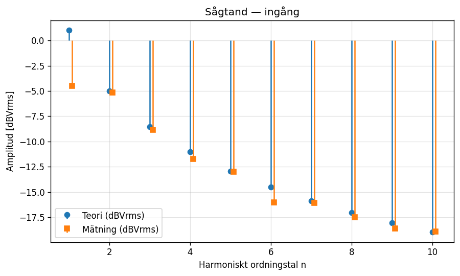

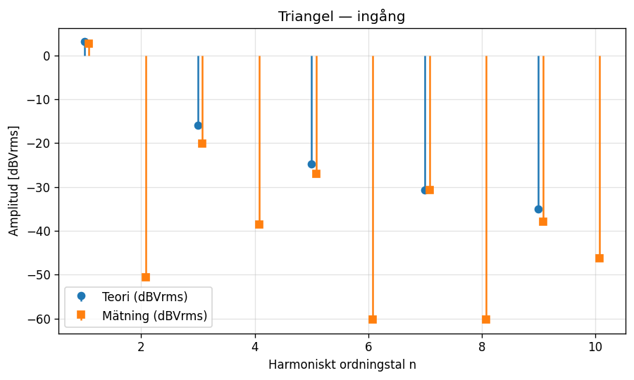

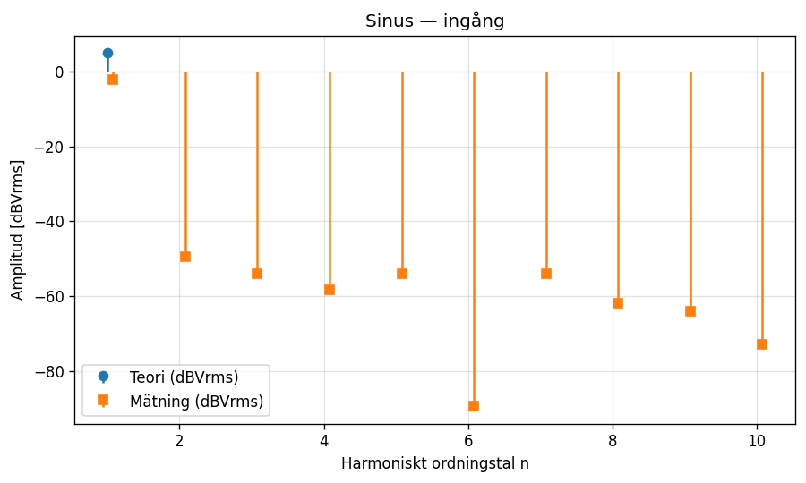

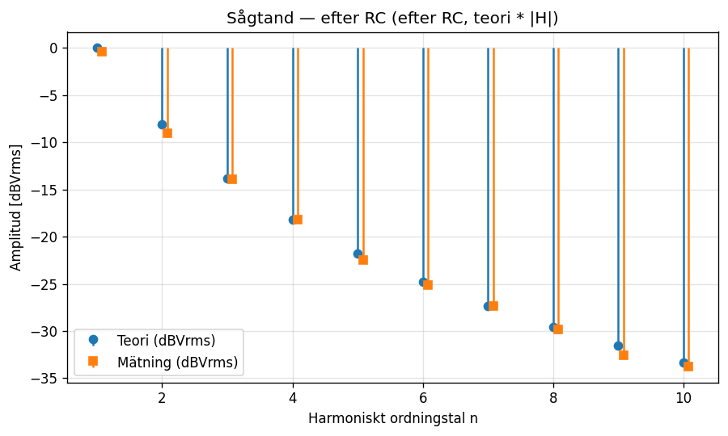

|  | n | f_target_Hz | f_bin_Hz | meas_dBVrms | f_Hz | theory_dBVrms | err_dB |
| --- | --- | --- | --- | --- | --- | --- | --- |
| 0 | 1 | 1000.0 | 1001.358032 | -0.417003 | 1000.0 | 0.003643 | -0.420646 |
| 1 | 2 | 2000.0 | 1997.947692 | -9.055858 | 2000.0 | -8.136987 | -0.918872 |
| 2 | 3 | 3000.0 | 2999.305724 | -13.886599 | 3000.0 | -13.817135 | -0.069463 |
| 3 | 4 | 4000.0 | 4000.663756 | -18.198600 | 4000.0 | -18.214411 | 0.015812 |
| 4 | 5 | 5000.0 | 5002.021787 | -22.476204 | 5000.0 | -21.782140 | -0.694065 |
| 5 | 6 | 6000.0 | 5998.611448 | -25.088529 | 6000.0 | -24.772041 | -0.316488 |
| 6 | 7 | 7000.0 | 6999.969479 | -27.336981 | 7000.0 | -27.339369 | 0.002388 |
| 7 | 8 | 8000.0 | 8001.327511 | -29.835767 | 8000.0 | -29.585763 | -0.250004 |
| 8 | 9 | 9000.0 | 8997.917171 | -32.601840 | 9000.0 | -31.580898 | -1.020942 |
| 9 | 10 | 10000.0 | 9999.275203 | -33.761688 | 10000.0 | -33.374370 | -0.387317 |

```python
%pip install -q numpy pandas matplotlib

# === ELA24: Comparisons in dBVrms (no files written) ===
import numpy as np
import pandas as pd
import matplotlib.pyplot as plt
from pathlib import Path

plt.rcParams['figure.dpi'] = 120
plt.rcParams['figure.figsize'] = (7.6, 4.6)

# ----- Lab params (edit to match your setup) -----
F0      = 1000.0          # [Hz] fundamental
VPP     = 5.0             # [Vpp] generator-level for theory
A       = VPP/2.0         # [Vpeak]
N_HARM  = 10              # compare first N harmonics
R, C    = 8200.0, 10e-9   # RC low-pass values (8.2k, 10nF)
FC      = 1.0/(2*np.pi*R*C)

# ----- Helpers -----
def vrms_to_dBVrms(vrms, floor=1e-12):
    v = np.maximum(np.asarray(vrms, float), floor)
    return 20.0*np.log10(v)

def rc_mag(f, fc=FC):
    f = np.asarray(f, float)
    return 1.0/np.sqrt(1.0 + (f/fc)**2)

# ----- Fourier theory -> dBVrms -----
def sawtooth_dBVrms(n, A=A):
    n = np.asarray(n, int)
    vpk = 2.0*A/(np.pi*np.maximum(n,1))
    vrms = vpk/np.sqrt(2.0)
    return vrms_to_dBVrms(vrms)

def triangle_dBVrms(n, A=A):
    n = np.asarray(n, int)
    vrms = np.zeros_like(n, float)
    odd = (n % 2 == 1)
    vpk_odd = 8.0*A/(np.pi**2 * np.maximum(n[odd],1)**2)
    vrms[odd] = vpk_odd/np.sqrt(2.0)
    dB = vrms_to_dBVrms(vrms)
    dB[~odd] = np.nan   # jämna = ingen harmonisk → NaN (inget ritas)
    return dB

def sine_dBVrms(n, A=A):
    n = np.asarray(n, int)
    vrms = np.zeros_like(n, float)
    vrms[n == 1] = A/np.sqrt(2.0)   # bara fundamental
    dB = vrms_to_dBVrms(vrms)
    dB[n != 1] = np.nan             # alla andra = ingen harmonisk
    return dB


def theory_dBVrms(F0=F0, N=N_HARM, waveform='saw', apply_rc=False):
    n = np.arange(1, N+1)
    if waveform == 'saw':
        dB = sawtooth_dBVrms(n)
    elif waveform == 'tri':
        dB = triangle_dBVrms(n)
    elif waveform == 'sin':
        dB = sine_dBVrms(n)
    else:
        raise ValueError("waveform must be 'saw' | 'tri' | 'sin'")
    if apply_rc:
        dB += vrms_to_dBVrms(rc_mag(n*F0))  # add 20*log10|H|
    return pd.DataFrame({'n': n, 'f_Hz': n*F0, 'theory_dBVrms': dB})

# ----- Scope CSV (Vrms) -> spectrum (dBVrms) -----
def read_scope_fft_vrms(csv_path):
    """
    Robust reader: handles semicolon sep, decimal comma, headers/garbage.
    Returns columns: freq[Hz], Vrms, dBVrms
    """
    raw = pd.read_csv(csv_path, sep=';', header=None, engine='python', dtype=str)
    freqs, mags = [], []
    for _, row in raw.iterrows():
        nums = []
        for cell in row.dropna():
            s = cell.strip()
            if not s:
                continue
            s = s.replace(',', '.')
            try:
                nums.append(float(s))
            except ValueError:
                pass
        if len(nums) >= 2:
            f, v = nums[-2], nums[-1]  # assume last two numeric fields = freq, Vrms
            if f >= 0 and v >= 0:
                freqs.append(f); mags.append(v)
    spec = pd.DataFrame({'freq': freqs, 'Vrms': mags}).sort_values('freq')
    spec = spec.drop_duplicates(subset=['freq']).reset_index(drop=True)
    if spec.empty:
        raise ValueError(f"No numeric data parsed from {csv_path}")
    spec['dBVrms'] = vrms_to_dBVrms(spec['Vrms'].values)
    return spec

def pick_harmonic_bins(spec_df, F0, N_HARM):
    """Nearest bin to n·F0 for n=1..N within spectrum span."""
    freqs = spec_df['freq'].values
    n_all = np.arange(1, N_HARM+1)
    targets = n_all*F0
    ok = (targets >= freqs[0]) & (targets <= freqs[-1])
    n = n_all[ok]; targets = targets[ok]
    idx = np.searchsorted(freqs, targets)
    idx = np.clip(idx, 1, len(freqs)-1)
    chosen = np.where(np.abs(freqs[idx]-targets) < np.abs(freqs[idx-1]-targets), idx, idx-1)
    return pd.DataFrame({
        'n': n,
        'f_target_Hz': targets,
        'f_bin_Hz': freqs[chosen],
        'meas_dBVrms': spec_df['dBVrms'].values[chosen],
    })

# ----- One-shot comparison plot -----
def compare_plot(csv_path, waveform, apply_rc_to_theory=False, title=None,
                 F0=F0, N=N_HARM):
    spec = read_scope_fft_vrms(csv_path)
    meas = pick_harmonic_bins(spec, F0, N)
    theo = theory_dBVrms(F0=F0, N=N, waveform=waveform, apply_rc=apply_rc_to_theory)
    df = meas.merge(theo, on='n', how='left')
    df['err_dB'] = df['meas_dBVrms'] - df['theory_dBVrms']

    plt.figure()
    plt.stem(df['n'],       df['theory_dBVrms'], linefmt='C0-', markerfmt='C0o', basefmt=" ",
             label='Teori (dBVrms)')
    plt.stem(df['n']+0.08,  df['meas_dBVrms'],   linefmt='C1-', markerfmt='C1s', basefmt=" ",
             label='Mätning (dBVrms)')
    plt.xlabel('Harmoniskt ordningstal n'); plt.ylabel('Amplitud [dBVrms]')
    ttl = title or f'{Path(csv_path).name} — {waveform.upper()}'
    if apply_rc_to_theory: ttl += ' (efter RC, teori * |H|)'
    plt.title(ttl); plt.grid(True, alpha=0.35); plt.legend(); plt.tight_layout(); plt.show()

    return df  # handy to inspect errors inline if you want

# ===== Examples matching the lab comparisons =====
# 1) Sågtand före filtret (teori vs mätning, dBVrms)
compare_plot("trace_saw_fft.csv", waveform='saw', apply_rc_to_theory=False, title="Sågtand — ingång")

# 2) Triangel före filtret
compare_plot("trace_triangle_fft.csv", waveform='tri', apply_rc_to_theory=False, title="Triangel — ingång")

# 3) Sinus före filtret (endast grundton)
compare_plot("trace_sine_fft.csv", waveform='sin', apply_rc_to_theory=False, title="Sinus — ingång")

# 4) Sågtand efter RC (jämför mot teori multiplicerad med |H(jω)|)
compare_plot("rc_fft_1khz.csv", waveform='saw', apply_rc_to_theory=True, title="Sågtand — efter RC")
```

```python
# Compute cutoff using measured R and C values (for reference)
R_meas = 8140.0        # ohms (Fluke 155)
C_meas = 9.853e-9      # farads (Agilent U1731C)
fc_meas = 1.0/(2*np.pi*R_meas*C_meas)
print(f"Measured fc ≈ {fc_meas:.2f} Hz")
```

```
Measured fc ≈ 1984.39 Hz
```

## Sawtooth: input vs after RC — measurement vs measurement

We directly compare the measured spectra for the sawtooth at the input (`trace_saw_fft.csv`) and after the RC filter (`rc_fft_1khz.csv`). Two overlays are shown:

- dBVrms per harmonic (absolute levels)
- dBc per harmonic relative to each dataset’s own fundamental (shape only)

A small table summarizes per-harmonic attenuation (after RC − input) in dB.

## Representative figures (time & frequency)

Your oscilloscope screenshots (time traces and FFTs), listed with filenames for easy PDF export.

#### Time-Domain Waveforms (Input Signals)

[output not shown]

#### FFT Spectra (Measured)

[output not shown]

#### RC Filter Frequency Response / Effect (Selected Frequencies)

[output not shown]

(Additional views) Example higher‑frequency time traces illustrating stronger attenuation:

[output not shown]

> If an image fails to render in exported PDF, ensure the files are alongside the notebook, or embed them.

Time-Domain Waveforms (Input Signals)

Sawtooth

[figure not shown]

Triangle

[figure not shown]

Sine

[figure not shown]

After RC (filtered sawtooth)

[figure not shown]

FFT Spectra (Measured)

Sawtooth FFT

[figure not shown]

Triangle FFT

[figure not shown]

Sine FFT

[figure not shown]

RC Filter Frequency Response / Effect (Selected Frequencies)

RC response ~1 kHz

[figure not shown]

RC response ~10 kHz

[figure not shown]

RC response ~100 kHz

[figure not shown]

Additional time traces (RC output)

10 kHz time-domain

[figure not shown]

100 kHz time-domain

[figure not shown]

```python
# Embed representative figures for PDF export (inputs hidden by CSS; outputs show images)
from IPython.display import display, HTML, Image


def show_section(title, items):
    display(HTML(f"<h3 style='margin-top:1.2em'>{title}</h3>"))
    for label, path in items:
        display(HTML(f"<div style='font-weight:600;margin:0.4em 0'>{label}</div>"))
        try:
            display(Image(filename=path, embed=True))  # base64-embed ensures print visibility
        except Exception as e:
            display(HTML(f"<div style='color:#c00'>Missing image: {path} ({e})</div>"))

# Time-domain
time_imgs = [
    ("Sawtooth", "saw_signal.png"),
    ("Triangle", "triangle_signal.png"),
    ("Sine", "sine_signal.png"),
    ("After RC (filtered sawtooth)", "rc_signal.png"),
]
show_section("Time-Domain Waveforms (Input Signals)", time_imgs)

# FFT spectra
fft_imgs = [
    ("Sawtooth FFT", "saw_fft.png"),
    ("Triangle FFT", "triangle_fft.png"),
    ("Sine FFT", "sine_fft.png"),
]
show_section("FFT Spectra (Measured)", fft_imgs)

# RC frequency-response effects
rc_freq_imgs = [
    ("RC response ~1 kHz", "rc_fft_1khz.png"),
    ("RC response ~10 kHz", "rc_fft_10khz.png"),
    ("RC response ~100 kHz", "rc_fft_100khz.png"),
]
show_section("RC Filter Frequency Response / Effect (Selected Frequencies)", rc_freq_imgs)

# RC time-domain examples
rc_time_imgs = [
    ("10 kHz time-domain", "rc_10khz.png"),
    ("100 kHz time-domain", "rc_100khz.png"),
]
show_section("Additional time traces (RC output)", rc_time_imgs)
```

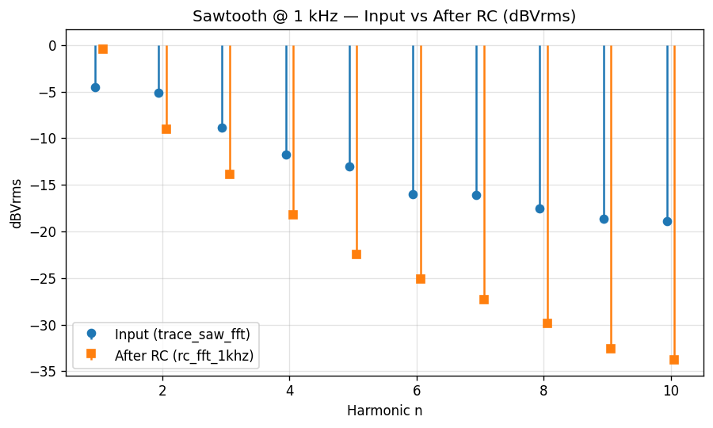

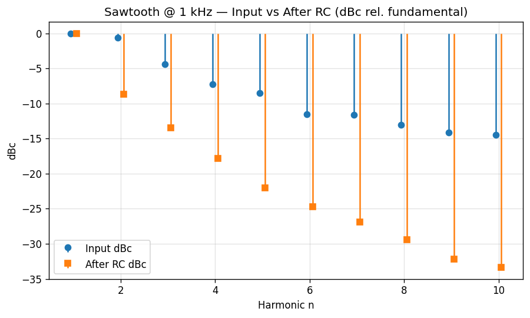

|  | n | meas_dBVrms_in | meas_dBVrms_out | attenuation_dB |
| --- | --- | --- | --- | --- |
| 0 | 1 | -4.482333 | -0.417003 | 4.065330 |
| 1 | 2 | -5.122092 | -9.055858 | -3.933766 |
| 2 | 3 | -8.846661 | -13.886599 | -5.039937 |
| 3 | 4 | -11.708367 | -18.198600 | -6.490233 |
| 4 | 5 | -12.986561 | -22.476204 | -9.489643 |
| 5 | 6 | -16.037172 | -25.088529 | -9.051357 |
| 6 | 7 | -16.069481 | -27.336981 | -11.267500 |
| 7 | 8 | -17.509711 | -29.835767 | -12.326057 |
| 8 | 9 | -18.607909 | -32.601840 | -13.993931 |
| 9 | 10 | -18.931827 | -33.761688 | -14.829861 |

```python
# Compare measured spectra: sawtooth input vs after RC
import numpy as np
import pandas as pd
import matplotlib.pyplot as plt
from IPython.display import display

F0_cmp = 1000.0
N_cmp = 10

# Reuse earlier helpers
# - read_scope_fft_vrms
# - pick_harmonic_bins (may return 'meas_dBVrms' or 'dBVrms')

spec_in = read_scope_fft_vrms('trace_saw_fft.csv')
spec_out = read_scope_fft_vrms('rc_fft_1khz.csv')

meas_in = pick_harmonic_bins(spec_in, F0_cmp, N_cmp)
meas_out = pick_harmonic_bins(spec_out, F0_cmp, N_cmp)

# Harmonize column names
if 'meas_dBVrms' not in meas_in.columns and 'dBVrms' in meas_in.columns:
    meas_in = meas_in.rename(columns={'dBVrms': 'meas_dBVrms'})
if 'meas_dBVrms' not in meas_out.columns and 'dBVrms' in meas_out.columns:
    meas_out = meas_out.rename(columns={'dBVrms': 'meas_dBVrms'})

# Merge on n to compare
cmp_df = pd.merge(meas_in[['n','meas_dBVrms']], meas_out[['n','meas_dBVrms']], on='n', how='inner', suffixes=('_in','_out'))

# Plot dBVrms overlay
plt.figure()
plt.stem(cmp_df['n']-0.06, cmp_df['meas_dBVrms_in'],  linefmt='C0-', markerfmt='C0o', basefmt=' ', label='Input (trace_saw_fft)')
plt.stem(cmp_df['n']+0.06, cmp_df['meas_dBVrms_out'], linefmt='C1-', markerfmt='C1s', basefmt=' ', label='After RC (rc_fft_1khz)')
plt.title('Sawtooth @ 1 kHz — Input vs After RC (dBVrms)')
plt.xlabel('Harmonic n'); plt.ylabel('dBVrms'); plt.grid(True, alpha=0.35); plt.legend(); plt.tight_layout(); plt.show()

# Plot dBc overlay (shape comparison)
ref_in = cmp_df.loc[cmp_df['n']==1, 'meas_dBVrms_in'].iloc[0] if (cmp_df['n']==1).any() else cmp_df['meas_dBVrms_in'].max()
ref_out = cmp_df.loc[cmp_df['n']==1, 'meas_dBVrms_out'].iloc[0] if (cmp_df['n']==1).any() else cmp_df['meas_dBVrms_out'].max()

dBc_in = cmp_df['meas_dBVrms_in'] - ref_in
dBc_out = cmp_df['meas_dBVrms_out'] - ref_out

plt.figure()
plt.stem(cmp_df['n']-0.06, dBc_in,  linefmt='C0-', markerfmt='C0o', basefmt=' ', label='Input dBc')
plt.stem(cmp_df['n']+0.06, dBc_out, linefmt='C1-', markerfmt='C1s', basefmt=' ', label='After RC dBc')
plt.title('Sawtooth @ 1 kHz — Input vs After RC (dBc rel. fundamental)')
plt.xlabel('Harmonic n'); plt.ylabel('dBc'); plt.grid(True, alpha=0.35); plt.legend(); plt.tight_layout(); plt.show()

# Table: attenuation per harmonic (after - input)
cmp_df['attenuation_dB'] = cmp_df['meas_dBVrms_out'] - cmp_df['meas_dBVrms_in']
display(cmp_df[['n','meas_dBVrms_in','meas_dBVrms_out','attenuation_dB']])
```

## Results (short summary)

- Sawtooth: Harmonics up to 10 kHz visible; amplitudes decay ≈ 1/n.
- Triangle: Odd harmonics only; amplitudes decay ≈ 1/n².
- Sine: Only the fundamental ideally; extra small peaks in practice stem from leakage/noise/distortion.
- RC filter: Attenuation increases with frequency (≈ −20 dB/dec above (f_c)); phase tends to −90°. The time waveform becomes smoother.

## Discussion

- Sawtooth vs triangle: Sawtooth contains all harmonics (1/n); triangle only odd harmonics with faster decay (1/n²). This reflects sharp edges vs smoother ramps.
- Sine: Ideally only one spectral line; extra lines indicate window leakage, noise floor, or source distortion.
- RC filter: The predicted attenuation $20\log_{10}|H|$ matches the observed trend. Deviations arise from probe loading, FFT bin resolution, window choice, and vertical scaling in dBVrms.
- Phase: The increasing negative phase with frequency explains the smoothing in time domain (harmonics lag more than the fundamental).

## References

- H. Hallenberg, Signalbehandling och kommunikationssystem, Yrgo, 2021.
- ELA24 – Laboration: Frekvensanalys (Lab PM) and Ledning Fourierlabben (guidance notes).
- Keysight/Tektronix oscilloscope FFT documentation (Hann window, dBVrms scaling).
- Standard RC low-pass theory (jω method, Bode magnitude/phase).